# Визуализация данных с помощью ggplot2, часть 1

## Статистические преобразования (stat)

Рассмотрим предыдущий график подробнее. На горизонтальной оси отображены значения переменной `hwy`, которую мы связали с эстетикой положения `x`. Однако на вертикальной оси мы видим переменную `count` (число наблюдений на интервале), которой не было в исходном наборе данных:

```r
names(mpg)
```

```
##  [1] "manufacturer" "model"        "displ"        "year"
##  [5] "cyl"          "trans"        "drv"          "cty"
##  [9] "hwy"          "fl"           "class"
```

Причина в том, что часто для визуализации исходные данные подвергаются преобразованиям. В нашем примере потребовалось разбить диапазон значений переменной `hwy` на интервалы заданной ширины и подсчитать количество наблюдений на каждом интервале.

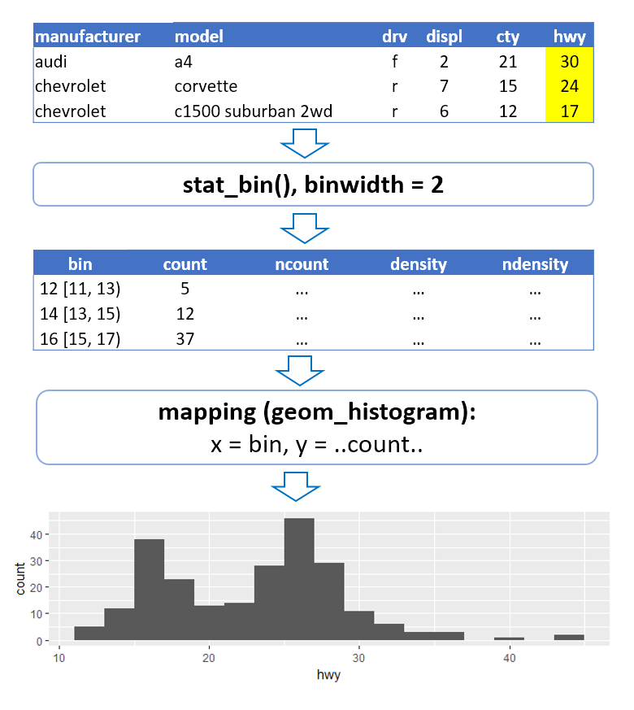

Применение статистической функции

В `ggplot2` любой геом связан с некоторым **статистическим преобразованием** (**stat**), которое применяется к данным. Например, в справке по `?geom_histogram` можно убедиться, что по умолчанию для этого геома используется статистическое преобразование - группировка в интервалы (**binning**): `stat = 'bin'`.

Статистические преобразования доступны в виде отдельных функций.

Имена статистических функций полезно знать, чтобы смотреть по ним справку. Также их можно добавлять как слои на визуализацию, т.к. каждая статистика связана по умолчанию с определенным геомом.

Имена этих функций формируются по шаблону: `stat_...()`. Например, функция для группировки в интервалы назыавется: `stat_bin()`.

В справке `?stat_bin` можно посмотреть, какие показатели (**Computed variables**) вычисляет эта функция:

- `count` - количество наблюдений на интервале (частота),
- `density` - плотность вероятности (площадь под кривой плотности = 1),
- `ncount` - нормированная частота, такая что максимальное значение частоты = 1 (удобно для сравнения распределений),
- `ndensity` - нормированная плотность.

Вычисленные показатели можно связывать с эстетиками. При этом, чтобы отличать их от переменных в исходном наборе данных, необходимо в начале и в конце имени вычисленного показателя добавлять `..`:

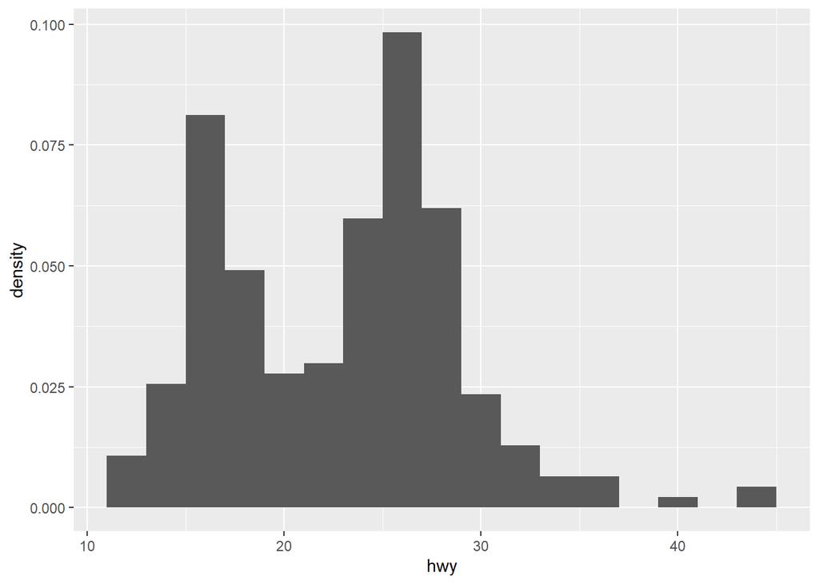

```r
ggplot(data = mpg) +
  geom_histogram(mapping =
                   aes(x = hwy, y = ..density..),
                 binwidth = 2)
```

**Замечание:** плотность вероятности выгодно отличается от частоты тем, что значения на оси `y` не зависят от заданной ширины интервалов:

$$d_i = \frac{n_i}{N \cdot \Delta_i}$$

В то время как при использовании частот, чем шире интервалы - тем выше частота.

Плотность распределения вычисленную эмпирически на основе данных, можно сравнивать с плотностью какого-либо предполагаемого распределения, например нормального. Как это сделать - можно посмотреть в блокноте `plotting_functions.Rmd`.

### Упражнение: гистограмма с нормированными частотами

Используя набор данных `diamonds`, постройте гистограмму веса бриллиантов (`carat`). На гистограмме должна отражаться нормированная частота. Подберите ширину интервала, которая, на ваш взгляд, хорошо подходит к этим данным (достаточное сглаживание, нет пустых интервалов).

```r
# Раскомментируйте и дополните код:
#ggplot(data = diamonds) +
#  geom_histogram(aes(x = ___, y = ___),
#                 binwidth = ___)
```

# Шкалы

**Шкалы** (**scales**) в `ggplot2` определяют, как именно соотносятся значения в данных и визуальные характеристики геометрических элементов. Например, какой цвет должен соответствовать огранке бриллианта `Ideal`, или в каком месте координатной оси должна располагаться точка со значением переменной `carat = 2`. В зависимости от типа визуализируемой переменной, `ggplot2` автоматически добавляет для нее дискретную (`discrete`) или непрерывную (`continuous`) шкалу, поэтому при разведочном анализе можно не заботиться о настройке шкал.

Однако настройка шкал позволяет сделать визуализацию более понятной, поэтому она часто нужна, когда вы хотите опубликовать свою визуализацию, или показать ее другим людям.

Вы можете:  
- использовать нелинейную (например, логарифмическую) шкалу для визуализации данных,  
- выбрать диапазон данных для визуализации, чтобы исключить выбросы, - изменить цветовую палитру графика, - задать шаг сетки и формат делений оси, - упорядочить категории на визуализации и в легенде.

Здесь мы рассмотрим только самые необходимые возможности. Более подробно со шкалами можно познакомиться в книге [R for Data Science](http://r4ds.had.co.nz/graphics-for-communication.html#scales).

## Нелинейные шкалы

Часто встречаются данные с асимметричным распределением. Из-за наличия выбросов (очень больших значений), основная масса наблюдений оказывается “прижатой” к началу координат и детали формы распределения не видны. Логарифмирование за счет “сжатия” шкалы позволяет лучше видеть форму распределения.

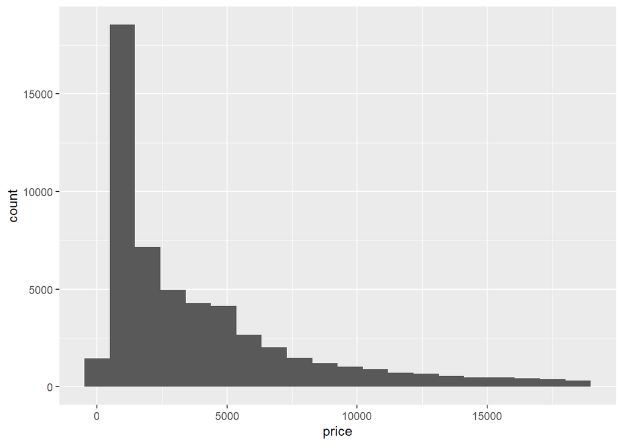

```r
# В исходной шкале
ggplot(data = diamonds) +
  geom_histogram(mapping = aes(x = price), bins = 20)
```

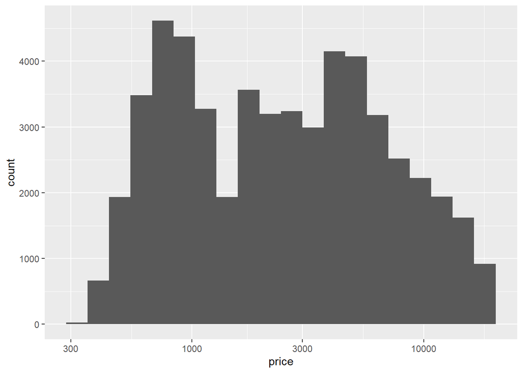

```r
# В логарифмической шкале
ggplot(data = diamonds) +
  geom_histogram(mapping = aes(x = price), bins = 20) +
  scale_x_log10()
```

### Упражнение: нелинейные шкалы

Ранее вы построили визуализацию зависимости цены бриллианта от веса для разных классов огранки. Разброс значений цен и веса бриллиантов очень большой, а зависимость цены от веса - нелинейная. Ваша задача - попробовать “распрямить” эту зависимость за счет использования нелинейной шкалы.

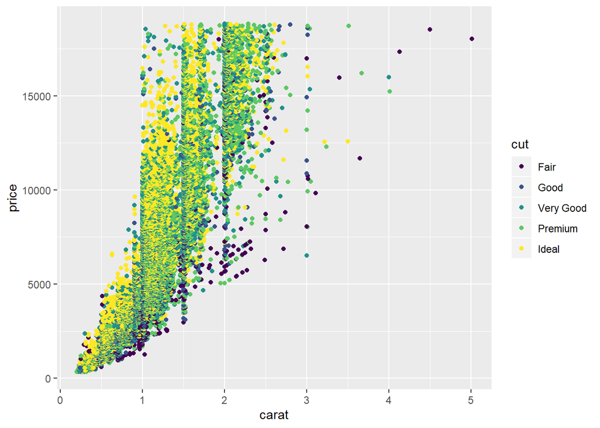

```r
# Используйте нелинейные шкалы, чтобы "распрямить" зависимость
ggplot(data = diamonds) +
  geom_point(mapping =
               aes(x = carat, y = price,
                   colour = cut))
```

**Подсказки:**

- Возможно, вам потребуется изменить шкалу для обеих координатных осей (`scale_x_...()`, `scale_y_...()`).
- Попробуйте использовать функции логарифмического преобразования (`scale_..._log10()`) или квадратного корня (`scale_..._sqrt()`)

## Другие возможности шкал

В **Приложении 1** рассмотрены вопросы выбора цветовой палитры и настройки шага сетки и делений шкалы. В **Приложении 2** показано, как выбрать области данных для визуализации.

# Системы координат

Шкалы связывают значения в таблице данных с положением геомов в некоторой системе координат. Однако чтобы увидеть данные, необходимо еще спроецировать эту систему координат на экран. Для этого в `ggplot2` используются **координатные системы** (`coord_...()`).

В большинстве случаев подходит выбранная по умолчанию система координат. Здесь мы рассмотрим несколько случаев, когда может потребоваться ее поменять.

## Пример: визуализация географических данных

В наборе данных `airports` содержится список аэропортов США с географическими координатами - широтой и долготой.

```r
library(nycflights13)
head(airports)
```

```
## # A tibble: 6 x 8
##   faa   name                       lat   lon   alt    tz dst   tzone
##   <chr> <chr>                    <dbl> <dbl> <int> <dbl> <chr> <chr>
## 1 04G   Lansdowne Airport         41.1 -80.6  1044    -5 A     America/New~
## 2 06A   Moton Field Municipal A~  32.5 -85.7   264    -6 A     America/Chi~
## 3 06C   Schaumburg Regional       42.0 -88.1   801    -6 A     America/Chi~
## 4 06N   Randall Airport           41.4 -74.4   523    -5 A     America/New~
## 5 09J   Jekyll Island Airport     31.1 -81.4    11    -5 A     America/New~
## 6 0A9   Elizabethton Municipal ~  36.4 -82.2  1593    -5 A     America/New~
```

Попробуем визуализировать эти данные на диаграмме рассеяния:

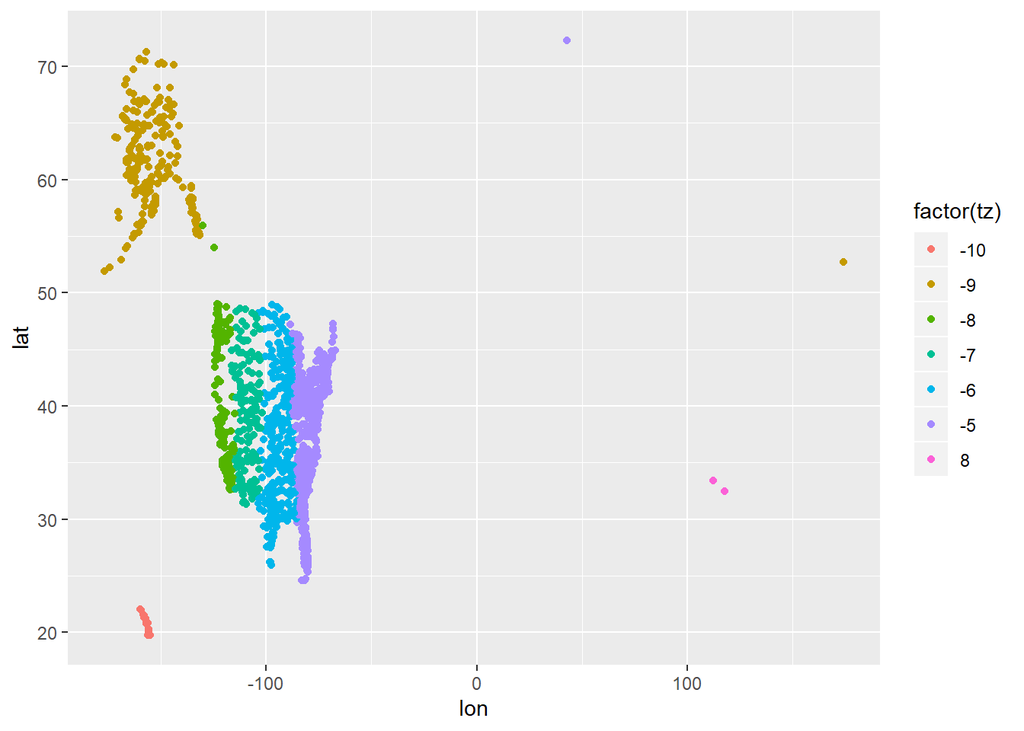

```r
ggplot(data = airports) +
  geom_point(mapping = aes(x = lon, y = lat, color = factor(tz)))
```

Форма американского континента выглядит странно, поскольку использование географических координат (на глобусе) в качестве декартовых координат (на плоскости) - грубое приближение. Чтобы получить привычный вид карты, необходимо выбрать координатную систему, которая выполняет картографическую проекцию этих данных.

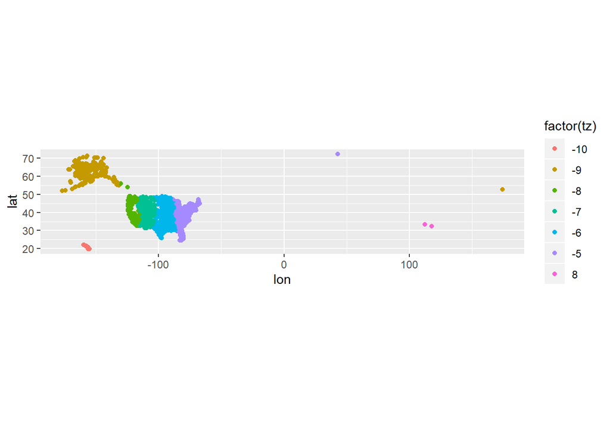

```r
ggplot(data = airports) +
  geom_point(mapping = aes(x = lon, y = lat, color = factor(tz))) +
  coord_quickmap()
```

Теперь очертания континента более узнаваемы.

С помощью `ggplot2` можно сделать и настоящую карту - см. ресурсы:

- [ggmap](http://stat405.had.co.nz/ggmap.pdf)
- [maps](https://rpubs.com/markpayne/134739)
- [Beautiful thematic maps with ggplot2](https://timogrossenbacher.ch/2016/12/beautiful-thematic-maps-with-ggplot2-only/)

## Пример: транспонирование осей

Встроенные геомы `ggplot2` - например, столбиковые диаграммы, предполагают, что категориальные переменные всегда расположены по оси `x`. Это может быть неудобно из-за наложения меток категорий. Вы можете транспонировать оси координат, чтобы метки располагались на вертикальной оси и их можно было прочитать легко.

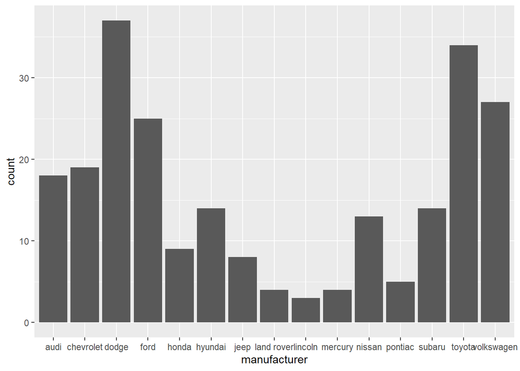

```r
# Стандартное расположение - категории по оси X
ggplot(data = mpg) +
  geom_bar(mapping = aes(x = manufacturer))
```

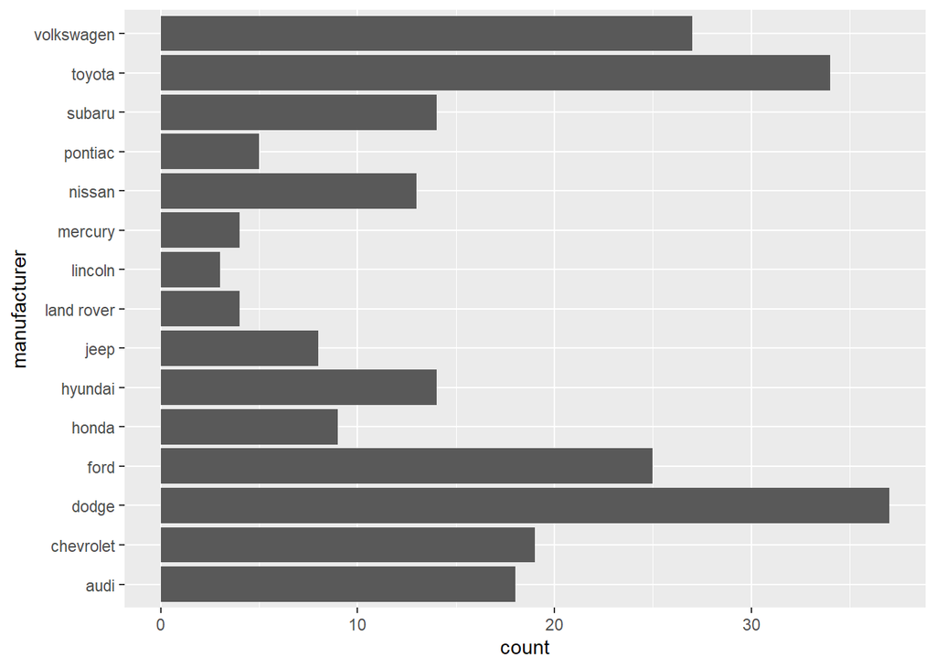

```r
# Транспонирование
ggplot(data = mpg) +
  geom_bar(mapping = aes(x = manufacturer)) +
  coord_flip()
```

## Другие возможности координатных систем

В приложении 2 рассмотрен пример масштабирования области графика с помощью шкал и координатной системы.

Более подробно можно познакомиться с координатными системами в [руководстве по ggplot2](http://ggplot2.tidyverse.org/reference/#section-coordinate-systems).

# Сравнение групп

Сравнение групп по некоторому количественному показателю - это часто используемый прием анализа зависимостей. Мы рассмотрим несколько способов сравнения групп.

## Ящичные диаграммы

**Ящичные диаграммы** (box plot) позволяют представить форму распределения количественной переменной в компактной форме и очень удобны для сравнения групп. В качестве примера, сравним топливную эффективность автомобилей с разным типом привода.

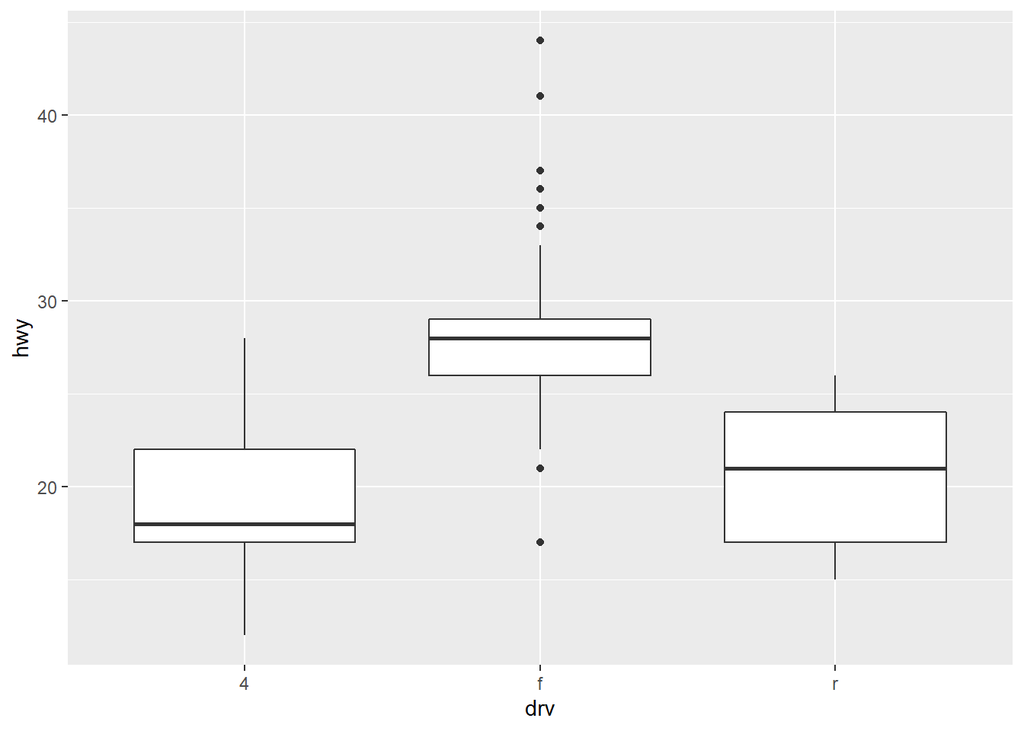

```r
ggplot(data = mpg) +
  geom_boxplot(mapping = aes(x = drv, y = hwy))
```

Обратите внимание, что категориальная переменная должна обязательно связываться с эстетикой `x`, а количественная - с `y`. При необходимости, вы можете развернуть ящики с помощью `coord_flip()`.

В `ggplot2` для построения ящичных диаграмм обяазательно надо указывать обе эстетики - `x` (переменная, которая задает группы) и `y` (количественный показатель для сравнения). Поэтому ящичную диаграмму без разделения на группы построить нельзя. Но можно “обмануть” программу, задав в качестве переменной для группировки константу.

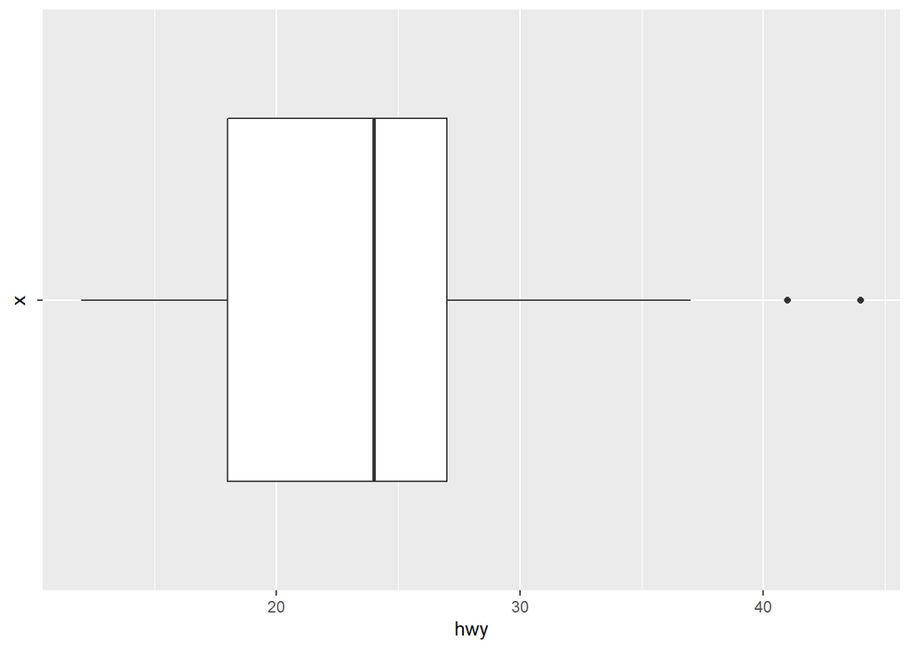

```r
ggplot(data = mpg) +
  geom_boxplot(mapping = aes(x = '', y = hwy)) +
  coord_flip()
```

## Полигоны частот

**Полигон частот** (frequency polygon) - это аналог гистограммы, однако вместо столбиков в нем используются линии. Это позволяет сравнивать на одном графике несколько распределений. Необходимо использовать `geom_freqpoly()` и связывать количественный показатель с эстетикой `x`, а категориальную переменную - с `color`.

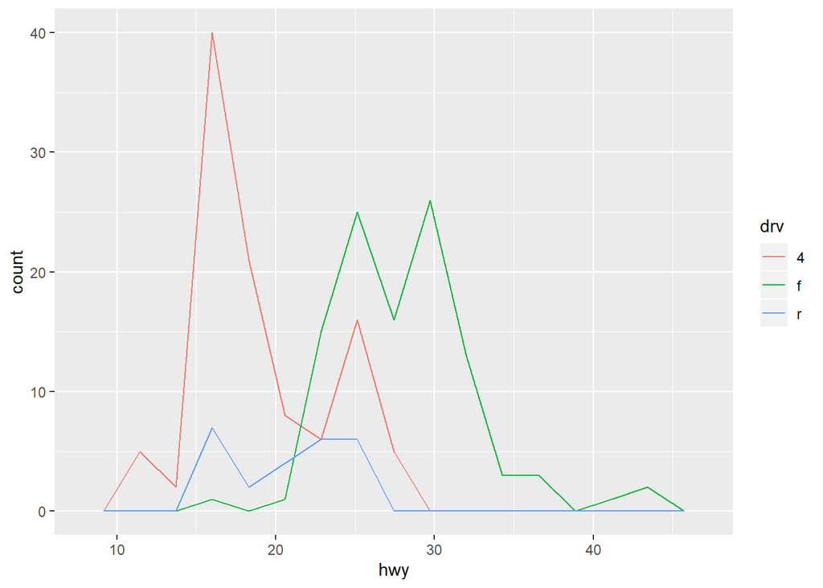

```r
ggplot(data = mpg) +
  geom_freqpoly(mapping = aes(x = hwy, color = drv),
                bins = 15)
```

По умолчанию, график строится по абсолютным частотам. Это неудобно, когда количество наблюдений в подгруппах сильно различается, малочисленные группы “прижимаются” к горизонтальной оси. Для более наглядного сравнения можно использовать либо нормированные частоты, либо посчитать относительные частоты наблюдений.

При нормировке каждый полигон масштабируется таким образом, чтобы максимальная частота была равной 1.

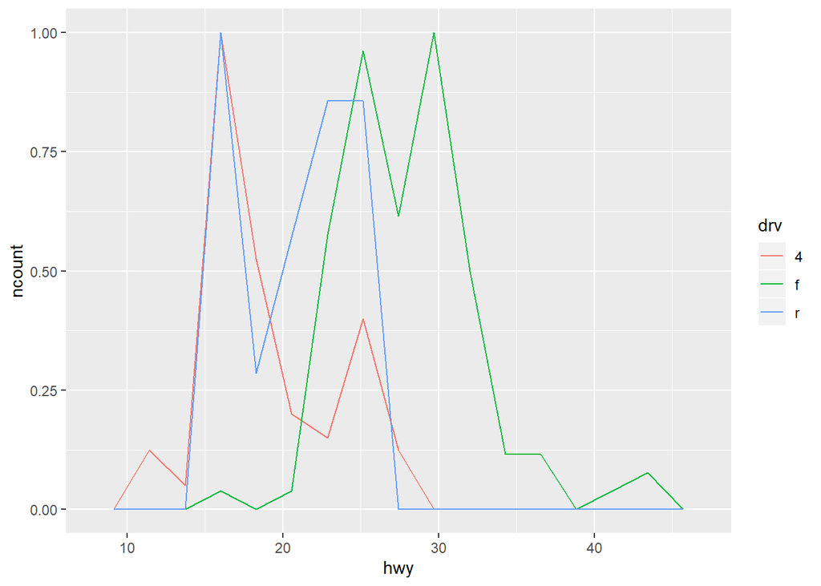

```r
ggplot(data = mpg) +
  geom_freqpoly(mapping = aes(x = hwy, y = ..ncount..,
                              color = drv),
                bins = 15)
```

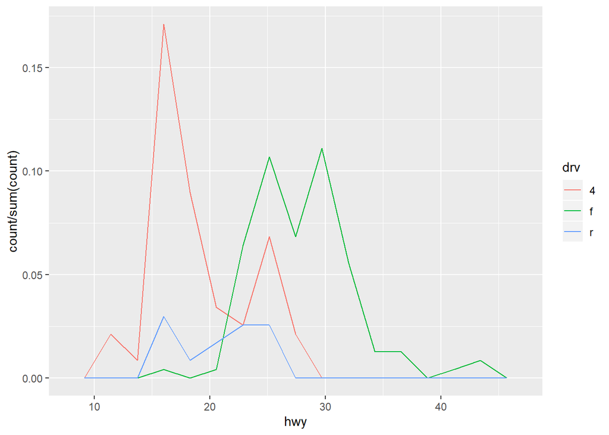

```r
ggplot(data = mpg) +
  geom_freqpoly(mapping =
                  aes(x = hwy,
                      y = ..count.. / sum(..count..), # доля от общего числа наблюдений
                      color = drv),
                bins = 15)
```

## Панели (facets)

Еще одним способом анализа зависимостей в `ggplot2` является **расщепление на панели** (**faceting**). Вы можете разделить набор данных на подгруппы по значению одной или двух категориальных переменных. После этого для каждой группы будет построен отдельный график.

### Пример: расщепление на панели по одной переменной - `facet_wrap()`

Когда переменная для расщепления одна, удобно использовать функцию `facet_wrap()`. Используем ее для сравнения гистограмм распределений топливной эффективности автомобилей с разным типом привода. Гистограммы удобнее сравнивать, когда они расположены одна под другой, поэтому мы ограничим число столбцов одним с помощью аргумента `ncol =`. Вспомним также о необходимости нормировки частот.

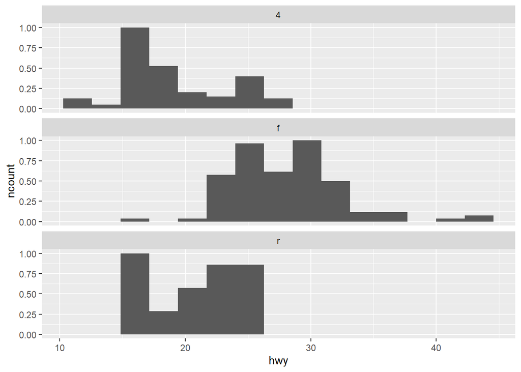

```r
ggplot(data = mpg) +
  geom_histogram(mapping =
                   aes(x = hwy, y = ..ncount..),
                 # или: y = ..count.. / sum(..count..)
                bins = 15) +
  facet_wrap(~ drv, ncol = 1)
```

Сравнивая гистограммы распределений на панелях, мы видим, что эффективность машин с передним приводом (`f`) выше, а полноприводные машины (`4`) имеют меньший пробег на галлоне топлива. Таким образом, здесь мы видим связь объясняющей переменной (`drv`) и зависимой переменной (`hwy`).

**Замечание:** обратите внимание на необходимость добавить тильду `~` перед именем переменной для расщепления. Вообще, в синтаксисе **формул** R принято, что справа от тильды указывается объясняющая переменная (фактор).

### Пример: расщепление на панели по двум переменным - `facet_grid()`

Расщепление на панели можно сделать и по двум переменным. В этом случае, необходимо использовать функцию `facet_grid()`. В качестве аргумента, этой функции надо передать **формулу** вида: `a ~ b`, где `a` - переменная, по которой будут формироваться строки, а `b` - переменная для формирования столбцов.

В качестве примера, изучим зависимость цены от веса бриллианта в категориях с различной огранкой и прозрачностью.

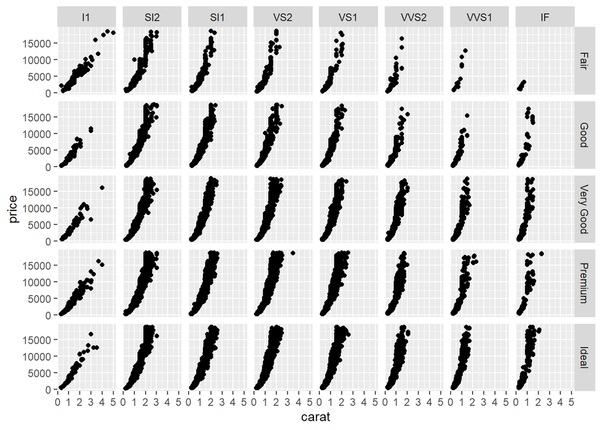

```r
ggplot(data = diamonds) +
  geom_point(mapping = aes(x = carat, y = price)) +
  facet_grid(cut ~ clarity)
```

### Упражнение: сравнение групп

Используя набор данных `mpg`, сравните топливную эффективность автомобилей на трассе (`hwy`) в зависимости от класса машины (`class`) и типа привода (`drv`). Какой из рассмотренных в этом разделе способов лучше всего подходит для этой задачи?

```r
# Напишите свой код здесь:
```

# Приложение 1. Работа со шкалами

## Выбор цветовой шкалы

При связывании переменных с эстетиками цвета `fill` или `color` в зависимости от вида переменной - непрерывная или дискретная - выбирается автоматически цветовая шкала. Для непрерывных переменных используется градиент. Для дискретных переменных выбираются максимально отстоящие друг от друга на цветовом круге оттенки цвета (**hue**). В пакете `ggplot2` используется цветовое пространство [HCL](http://www.hclwizard.org/why-hcl/).

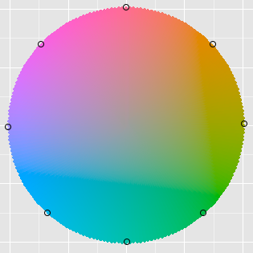

Цветовой круг

Данный выбор не всегда является оптимальным.

Для визуализации данных был специально разработан набор цветовых шкал `ColorBrewer` (по фамилии разработчика - Cynthia Brewer). Шкалы разрабатывались, в первую очередь, для создания [картограмм](http://colorbrewer2.org/#type=qualitative&scheme=Accent&n=5), однако их можно использовать для любых типов визуализаций. Шкалы разработаны с учетом того, что некоторые люди не различают определенные цвета.

В R эти шкалы реализованы в пакете `RColorBrewer`.

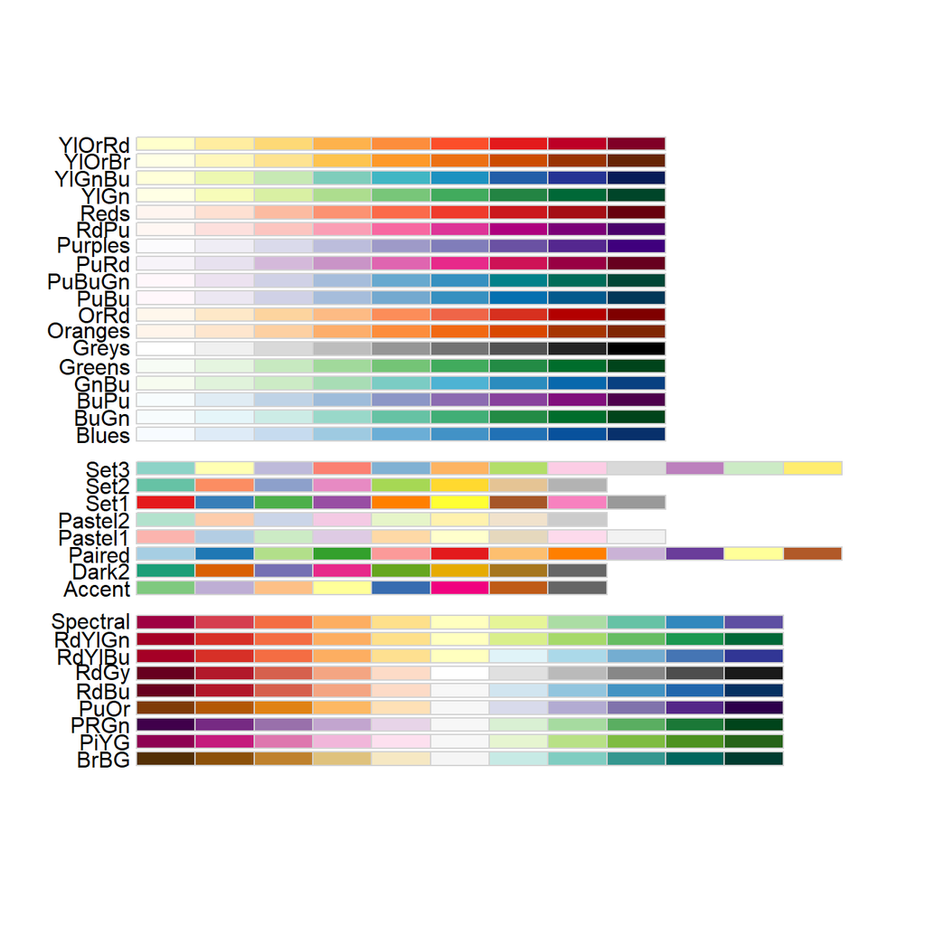

```r
RColorBrewer::display.brewer.all()
```

**Замечание:** запись `<имя пакета>::<имя функции>` позволяет обращаться к функции, реализованной в пакете, не подключая весь пакет. Также вы можете таким образом уточнить, о какой функции идет речь, если несколько пакетов содержат функции с одинаковыми именами.

Все шкалы ColorBrewer делятся на 3 категории:

- **Последовательные** (sequential) - для количественных переменных, имеющих абсолютный ноль (однонаправленных), или упорядоченных категориальных переменных. На рисунке это шкалы от `YlOrRd` до `Blues`.
- **Качественные** (qualitative) - для неупорядоченных категориальных переменных. На рисунке это шкалы от `Accent` до `Set3`.
- **Двунаправленные** (diverging) - для количественных переменных, имеющих некоторое “центральное значение” и направления больше/меньше от него. На рисунке это шкалы от `Spectral` до `BrBG`.

Шкалы обладают разной степенью цветовой насыщенности. Более “ядовитые” шкалы используются для небольших по размеру геомов - например, точек на диаграммах рассеяния. А для заливки больших площадей, - например, столбиков, - лучше подходят более спокойные оттенки.

Шкалы содержат дискретные цвета, поэтому при визуализации с их помощью непрерывные переменные необходимо дискретизировать (т.е. разбивать на интервалы).

### Пример использования шкалы ColorBrewer для категориальных данных

В `ggplot2` нужную цветовую шкалу для категориальных данных можно выбрать, используя функцию: `scale_color_brewer()` (для цвета границы) или `scale_fill_brewer()` (для цвета заливки). Показанное на рисунке имя шкалы надо указать в аргументе `palette =` этой функции.

См. также справку: `?scale_color_brewer`.

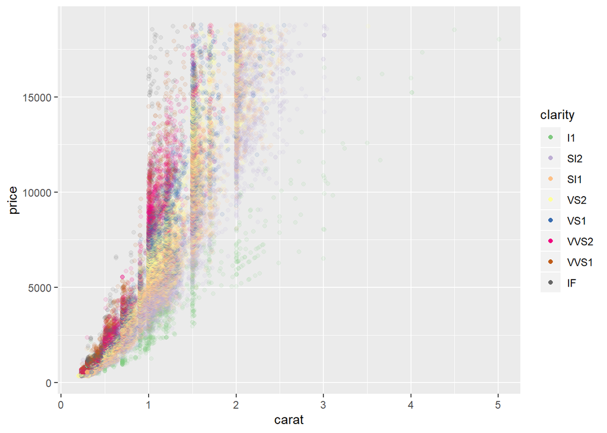

```r
ggplot(data = diamonds) +
  geom_point(mapping = aes(x = carat, y = price,
                           color = clarity),
             alpha = 0.1) +
  scale_color_brewer(palette = "Accent") +

  # не обязательно:
  guides(color = # не хотим прозрачность в легенде
           guide_legend(override.aes =
                          list(alpha = 1)))
```

### Пример использования цветовых шкал для непрерывных данных

Шкалы ColorBrewer создавались для визуализации дискретных значений - упорядоченных и неупорядоченных категорий. Однако их можно использовать и с непрерывными переменными. В `ggplot2` есть две функции - `scale_color_distiller()` и `scale_fill_distiller()` - соответственно, для цвета границы и заливки. Эти функции позволяют применять шкалы ColorBrewer к непрерывным данным. Они интерполируют дискретные цвета, включенные в шкалу. Палитра задается через аргумент `palette =`.

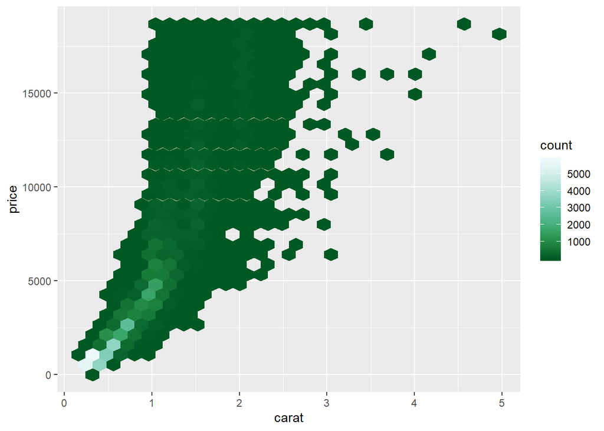

```r
ggplot(data = diamonds) +
  geom_hex(mapping = aes(x = carat, y = price)) +
  scale_fill_distiller(palette = "BuGn")
```

Специально для непрерывных данных была разработана еще одна цветовая шкала - [viridis](https://cran.r-project.org/web/packages/viridis/vignettes/intro-to-viridis.html). Эта шкала обеспечивает правильную передачу значений даже при черно-белой печати и при использовании людьми, не различающими некоторые цвета.

Для использования этой шкалы необходимо установить пакет `viridis`. После этого можно использовать функции: `viridis::scale_fill_viridis()`, `viridis::scale_color_viridis()`.

[figure not shown]

```r
ggplot(data = diamonds) +
  geom_hex(mapping = aes(x = carat, y = price)) +
  viridis::scale_fill_viridis()
```

**Замечание:** запись `<имя пакета>::<имя функции>` позволяет обращаться к функции, реализованной в пакете, не подключая весь пакет. Также вы можете таким образом уточнить, о какой функции идет речь, если несколько пакетов содержат функции с одинаковыми именами.